# Linkage Disequilibrium (LD)

LD statistics are computed from sequence variation data (e.g., 1000 Genomes Project).

**Utility:**

- Phenotypic association
- Evolutionary inference (gene flow, selective pressure)
- Imputation of linked variants

### Definitions

**Linkage Disequilibrium Coefficient $D$:**

$$D = h_{12} - p_1 \, p_2$$

where $h_{12}$ is the frequency of the haplotype carrying allele 1 at locus 1 and allele 2 at locus 2, and $p_1, p_2$ are allele probabilities.

**Squared Correlation $r^2$ (biallelic loci):**

$$r^2 = \frac{D^2}{\,p_A (1-p_A)\, p_B (1-p_B)\,}$$

**Allele association p-values:**

- Fisher’s exact test (for 2×2 tables)
- Chi-squared test (for >2×2 contingency tables)

### Derivation of $r^2$ for 2 loci, 2 alleles

Define indicator variables:

$$X =
\begin{cases}
1 & \text{if haplotype carries major allele at SNP1} \\
0 & \text{otherwise}
\end{cases},
\quad
Y =
\begin{cases}
1 & \text{if haplotype carries major allele at SNP2} \\
0 & \text{otherwise}
\end{cases}$$

Expectations:

$$E[X] = p_A, \quad E[Y] = p_B$$

Variances:

$$\mathrm{Var}(X) = p_A(1-p_A), \quad \mathrm{Var}(Y) = p_B(1-p_B)$$

Covariance:

$$\mathrm{Cov}(X,Y) = E[XY] - E[X]E[Y] = p_{AB} - p_A p_B = D$$

Correlation coefficient:

$$r = \frac{\mathrm{Cov}(X,Y)}{\sqrt{\mathrm{Var}(X)\, \mathrm{Var}(Y)}}
= \frac{D}{\sqrt{p_A(1-p_A)\, p_B(1-p_B)}}$$

Thus:

$$\boxed{r^2 = \frac{D^2}{\,p_A(1-p_A)\,p_B(1-p_B)\,}}$$

**References / Tools:**

- **LDpair:** Compute $D$ and $r^2$ for variant pairs (e.g., rs28574812 & rs2251399)
- **LDproxy:** Retrieve all SNPs’ $r^2$ relative to a SNP of interest
- **locuszoom plots** (for LD+GWAS)

## Task: Measure LD between two SNPs called in the [1000 Genomes Project](https://mccoy-lab.github.io/hgv_modules/the-1000-genomes-project.html) dataset

- [rs28574812](https://gnomad.broadinstitute.org/variant/21-15012619-A-G?dataset=gnomad_r3) (`chr21:15012619`)
- [rs2251399](https://gnomad.broadinstitute.org/variant/21-15013185-C-T?dataset=gnomad_r3) (`chr21:15013185`)

Every line in the table represents **one haplotype** in the 1000 Genomes database.

```r
# read data
haplotypes <- read.table("snp_haplotypes.txt", header = TRUE)

# preview data
head(haplotypes)
```

```
##    sample haplotype snp1_allele snp2_allele
## 1 HG00096     hap_1           A           C
## 2 HG00096     hap_2           A           C
## 3 HG00097     hap_1           A           C
## 4 HG00097     hap_2           A           C
## 5 HG00099     hap_1           A           C
## 6 HG00099     hap_2           A           C
```

```r
table <- table(haplotypes$snp1_allele, haplotypes$snp2_allele)

# Calculate p-value against linkage equilibrium (Fisher's Exact test for 2 alleles, 2 loci)
fisher.test(table)
```

```
##
##  Fisher's Exact Test for Count Data
##
## data:  table
## p-value < 2.2e-16
## alternative hypothesis: true odds ratio is not equal to 1
## 95 percent confidence interval:
##  22.49760 32.33934
## sample estimates:
## odds ratio
##    26.9124
```

```r
# More generally, Chi-squared can be used (>2x2)

# Here, A, C are major alleles of SNP1 and SNP2, respectively (i.e. subscripts 1 and 2)

# Measuring LD with D
h_12 <- table["A", "C"] / sum(table)
p_1 <- sum(table["A", ]) / sum(table)
p_2 <- sum(table[, "C"]) / sum(table)

D <- h_12 - p_1*p_2 # 0.14, positive in accordance with Fisher's test enrichment

D_primer <- function(D, p1, p2) {
    D_max = max(-p1*p2, -(1-p1)*(1-p2))
    D_min = min(p1*(1-p2), p2*(1-p1))

    if (D < 0) D_prime = D/D_max
    else if (D > 0) D_prime = D/D_min
    else D_prime = 0

    return(D_prime)
}

D_prime = D_primer(D, p_1, p_2)

print(D_prime) #0.81 - strong LD
```

```
## [1] 0.8058206
```

```r
r_squarer <- function(D, p1, p2) {
    D^2/( p1*(1-p1) * p2*(1-p2) )
}

r_squared <- r_squarer(D, p_1, p_2)
print(r_squared) # 0.38, moderate
```

```
## [1] 0.3773631
```

## LD & GWAS, locuszoom plot

The figure below is a **locuszoom plot** – a common visualization of data from **genome-wide association studies (GWAS)**. This particular study was a GWAS for genetic variants that impact mean corpuscular hemoglobin concentration.

- The left y-axis is the **p-value** for the association with mean corpuscular hemoglobin concentration
- Each variant is colored by its $\mathbf{r^2}$ with the top hit variant (in purple)
- The heatmap on the bottom shows **pairwise LD** between variants
- The right y-axis and dark blue line show the frequency of **recombination** events. Peaks are recombination hotspots (note how they line up with the boundaries of LD blocks in the heatmap)

This is a problem that affects all association studies. Two common ways of working around LD to identify causal variants are:

1. **[Statistical](https://royalsocietypublishing.org/doi/10.1098/rsob.190221) [fine](https://www.nature.com/articles/s41576-018-0016-z) [mapping](https://link.springer.com/article/10.1007/s00281-021-00902-8)**: Uses patterns of LD and statistical models to narrow down casual variant sets
2. **Experimental screening**: Tests candidate variants *in vitro* (ex: massively parallel reporter assays, CRISPR screens) to determine which have functional effects

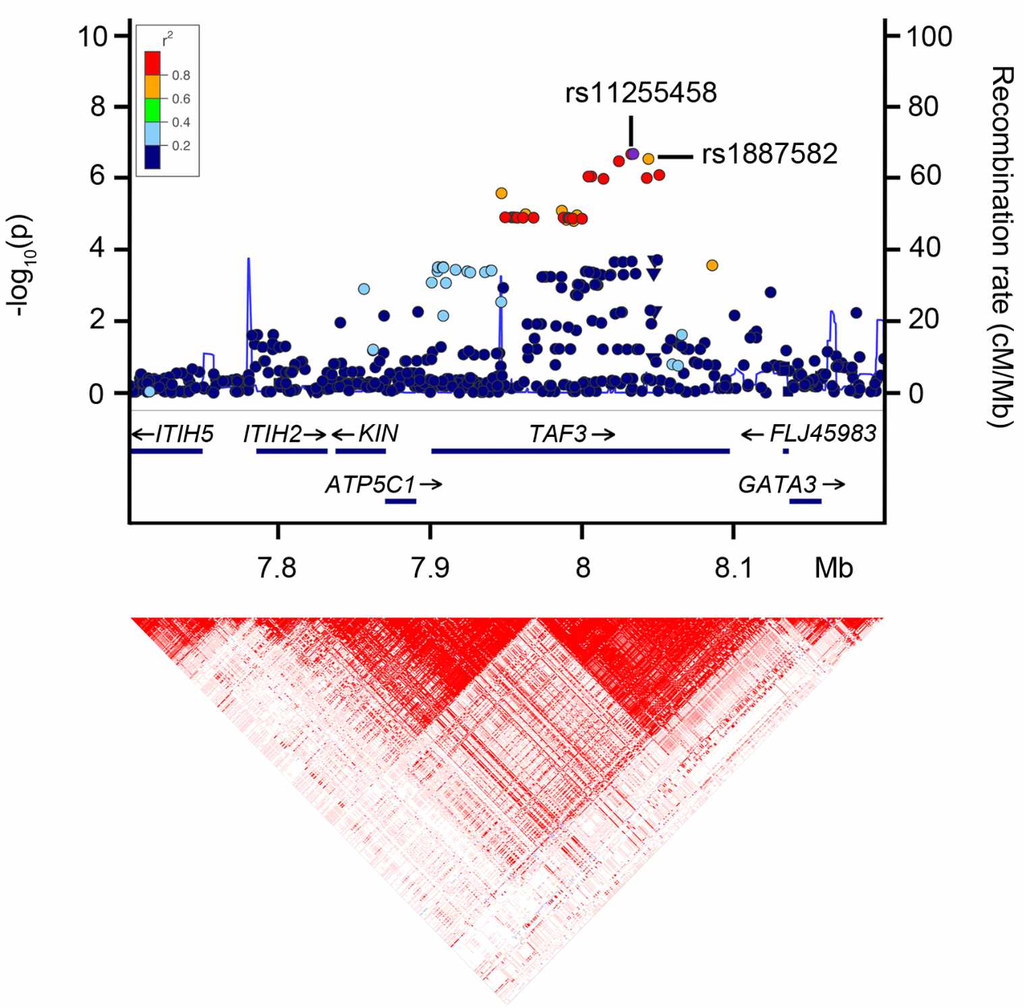

Fig. 7. GWAS associations with mean corpuscular hemoglobin concentration

## Assignment

For two different pair of SNPs:

- `chr21:15005329` and `chr21:15007704`
- `chr21:15336586` and `chr21:15336794`

**Calculate $D$, $D'$, and $r^2$ for these sets of SNPs. Which alleles are segregating together? What does each LD statistic indicate?**

```r
# read data for first set of SNPs
hw1 <- read.table("snp_haplotypes_hw1.txt", header = TRUE)

# read data for second set of SNPs
hw2 <- read.table("snp_haplotypes_hw2.txt", header = TRUE)
```

### TASK 1:

```r
# TASK 1:

table <- table(hw1$snp1_allele, hw1$snp2_allele)

#     A   G      < SNP2
# C  747 2508
# T  2   1751
# ^
# SNP1

# SNP1: 1 -> C (1=C, 0=T)
# SNP2: 2 -> A (1=A, 0=G)

p_1 <- sum(table["C", ]) / sum(table)
p_2 <- sum(table[, "A"]) / sum(table)

h_12 <- sum(table["C", "A"] / sum(table))

D <- h_12 - p_1 * p_2
D_prime <- D_primer(D, p_1, p_2)
r_squared <- r_squarer(D, p_1, p_2)
```

```
## Task 1 (`chr21:15005329` and `chr21:15007704`)
##  D = 0.0519529
##  D' = 0.99
##  r^2 = 0.093
```

```r
# D = 5.2%, D'=0.99, r^2=0.093
# Interpretation: High D', low r: In disequilibrium but not well correlated
#   - Conditionally rare SNP, 2=G doesn't well predict 1
```

### TASK 2:

```r
# TASK 2:

table <- table(hw2$snp1_allele, hw2$snp2_allele)

#     A   G      < SNP2
# A  3522 0
# G  0   1486
# ^
# SNP1

# SNP1: 1 -> A (1=A, 0=G)
# SNP2: 2 -> A (1=A, 0=G)


p_1 <- sum(table["A", ]) / sum(table)
p_2 <- sum(table[, "A"]) / sum(table)

h_12 <- sum(table["A", "A"] / sum(table))

D <- h_12 - p_1 * p_2
D_prime <- D_primer(D, p_1, p_2)
r_squared <- r_squarer(D, p_1, p_2)
```

[output not shown]

```r
# D = 21%, D'=1, r^2=1
# Maximal LD
```